# Connectivity Workshop

```julia
using Pkg
Pkg.activate(@__DIR__)
using SpeciesDistributionToolkit
using CairoMakie
const SDT = SpeciesDistributionToolkit

using Logging
global_logger(ConsoleLogger(stderr, Logging.Warn))
```

```
  Activating project at `~/Code/Workspaces/UQOWorkshop`
```

```
ConsoleLogger(IJulia.IJuliaStdio{Base.PipeEndpoint}(IOContext(Base.PipeEndpoint(RawFD(40) open, 0 bytes waiting))), ReentrantLock(), Info, Base.CoreLogging.default_metafmt, true, 0, Dict{Any, Int64}())
```

## Getting city boundaries as polygons with SDT

Fetch polygon boundaries from OpenStreetMap.

```julia
gatineau = getpolygon(PolygonData(OpenStreetMap, Places), place = "Gatineau")
ottawa   = getpolygon(PolygonData(OpenStreetMap, Places), place = "Ottawa");
```

Combine while maintaining separate features.

```julia
metro_region = vcat(ottawa, gatineau);
```

Combine into a single polygon.

```julia
ottawa + gatineau;
```

Quick visualization.

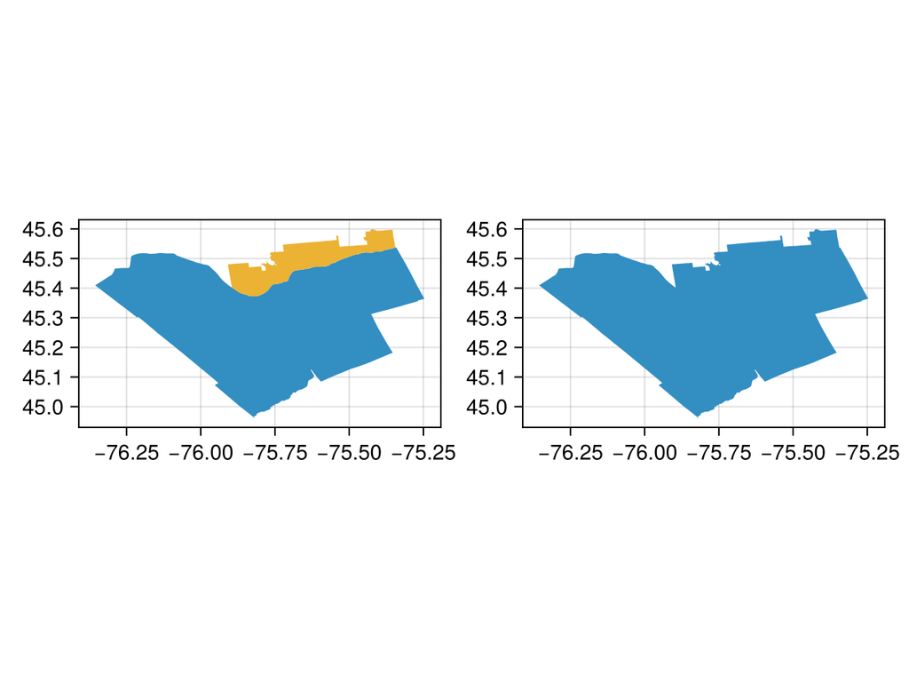

```julia
fig = Figure()
ax1, ax2 = Axis(fig[1,1], aspect=DataAspect()), Axis(fig[1,2], aspect=DataAspect())
poly!(ax1, metro_region)
poly!(ax2, ottawa + gatineau)
fig
```

Extract the bounding box as a named tuple.

```julia
SDT.boundingbox(metro_region)
```

```
(left = -76.35558319091797, right = -75.24658203125, bottom = 44.96177291870117, top = 45.599124908447266)
```

## Acquiring land cover data with SDT

The `RasterData` interface is used for all types of data from SDT. The pattern is `RasterData(SOURCE, DATA_TYPE)`.

All available data sources are subtypes of `RasterProvider`. To list all sources:

```julia
subtypes(RasterProvider)
```

```
7-element Vector{Any}:
 BiodiversityMapping
 CHELSA1
 CHELSA2
 Copernicus
 EarthEnv
 PaleoClim
 WorldClim2
```

Here we’ll use EarthEnv, a database of environmental data. Each `RasterProvider` provides one or more `RasterDataset`s, which correspond to particular types of data. We can list all of the different `RasterDataset`s available across all providers via:

```julia
subtypes(RasterDataset)
```

```
15-element Vector{Any}:
 AmphibianRichness
 AverageTemperature
 BioClim
 BirdRichness
 Elevation
 HabitatHeterogeneity
 LandCover
 MammalRichness
 MaximumTemperature
 MinimumTemperature
 Precipitation
 SolarRadiation
 Topography
 WaterVaporPressure
 WindSpeed
```

`RasterProvider`s do not typically provide every type of data, so we can use the following to determine what datasets are available from a particular provider. For example, this lists the datasets available from EarthEnv:

```julia
[ds for ds in subtypes(RasterDataset) if SimpleSDMDatasets.provides(EarthEnv, ds)]
```

```
2-element Vector{DataType}:
 HabitatHeterogeneity
 LandCover
```

An alternative way of doing this with traditional for loops:

```julia
for ds in subtypes(RasterDataset)
    if SimpleSDMDatasets.provides(EarthEnv, ds)
        println("EarthEnv provides $ds")
    end
end
```

```
EarthEnv provides HabitatHeterogeneity
EarthEnv provides LandCover
```

We will focus on the LandCover data provided by EarthEnv. We combine a `RasterProvider` and `RasterDataset` using the `RasterData` type:

```julia
dataset = RasterData(EarthEnv, LandCover)
```

```
RasterData{EarthEnv, LandCover}(EarthEnv, LandCover)
```

Many datasets provide multiple raster layers. We can list them with the `layers` method.

```julia
landcover_types = layers(dataset)
```

```
12-element Vector{String}:
 "Evergreen/Deciduous Needleleaf Trees"
 "Evergreen Broadleaf Trees"
 "Deciduous Broadleaf Trees"
 "Mixed/Other Trees"
 "Shrubs"
 "Herbaceous Vegetation"
 "Cultivated and Managed Vegetation"
 "Regularly Flooded Vegetation"
 "Urban/Built-up"
 "Snow/Ice"
 "Barren"
 "Open Water"
```

To load a layer we use the `SDMLayer` method. By default this loads the full extent of the first layer — a 17500 × 43200 pixel raster covering the whole Earth. We crop to our region of interest by passing the bounding box as keyword arguments. For example, to select the region between -90° and -85° longitude and 45° to 50° latitude:

```julia
SDMLayer(dataset; left = -90, right = -85, bottom = 45, top = 50);
```

We can also select a specific layer by passing its name as the `layer` keyword argument.

```julia
SDMLayer(dataset; layer = "Evergreen Broadleaf Trees", left = -90, right = -85, bottom = 45, top = 50);
```

For Ottawa/Gatineau we use the `SDT.boundingbox` method from earlier.

```julia
deciduous = SDMLayer(dataset; layer = "Deciduous Broadleaf Trees", SDT.boundingbox(metro_region)...);
```

Let’s visualize it.

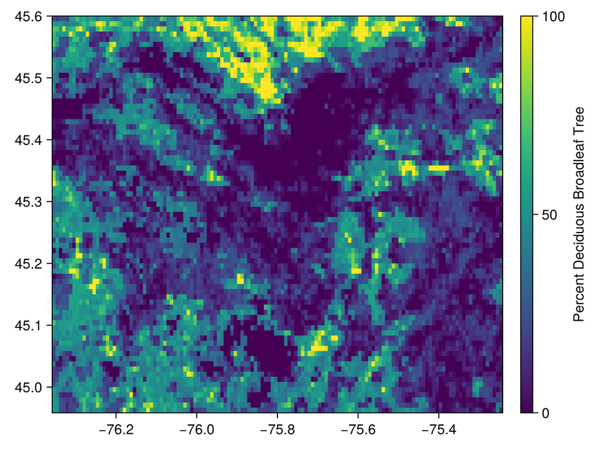

```julia
fig = Figure()
ax = Axis(fig[1,1])
hm = heatmap!(ax, deciduous)
Colorbar(fig[1,2], hm, label="Percent Deciduous Broadleaf Tree")
fig
```

This gives a score between 0 and 100 representing the percent of a pixel covered in deciduous broadleaf trees. Note that it covers the full bounding box of the region, not just the area inside the polygon. To mask cells outside the polygon we use `mask!`.

```julia
mask!(deciduous, metro_region);
```

We can visualize again to confirm.

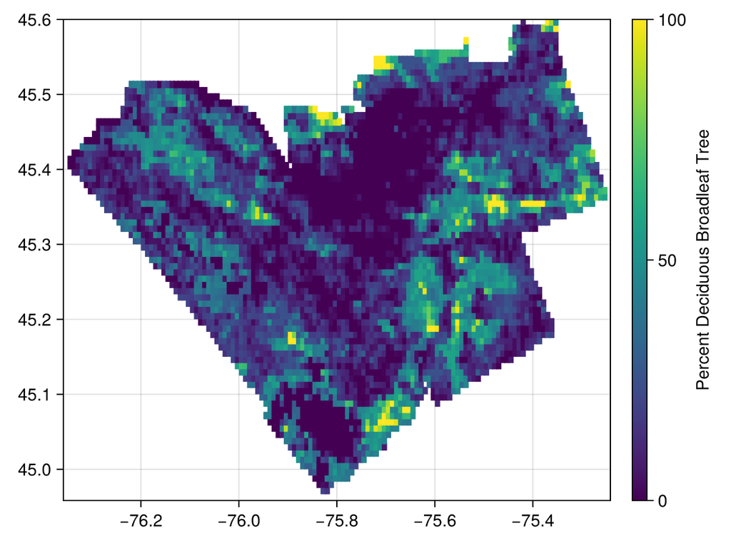

```julia
fig = Figure()
ax = Axis(fig[1,1])
hm = heatmap!(ax, deciduous)
Colorbar(fig[1,2], hm, label="Percent Deciduous Broadleaf Tree")
fig
```

For connectivity modeling we want a land cover map where each pixel is assigned a single discrete land cover type — the one most prominent in that pixel. The first step is to load the proportion cover for each category. Here’s one way using an inline loop:

```julia
stack = [
    SDMLayer(dataset;
        layer  = layer,
        SDT.boundingbox(metro_region)...
    )
    for layer in landcover_types
];
```

And an alternative using a traditional for loop:

```julia
stack = SDMLayer[]
for layer in landcover_types
    this_layer = SDMLayer(dataset; layer = layer, SDT.boundingbox(metro_region)...)
    push!(stack, this_layer)
end
```

We can apply `mask!` to the whole vector to include only cells within the region of interest.

```julia
mask!(stack, metro_region);
```

Let’s plot to get a glimpse of how multipanel plots work.

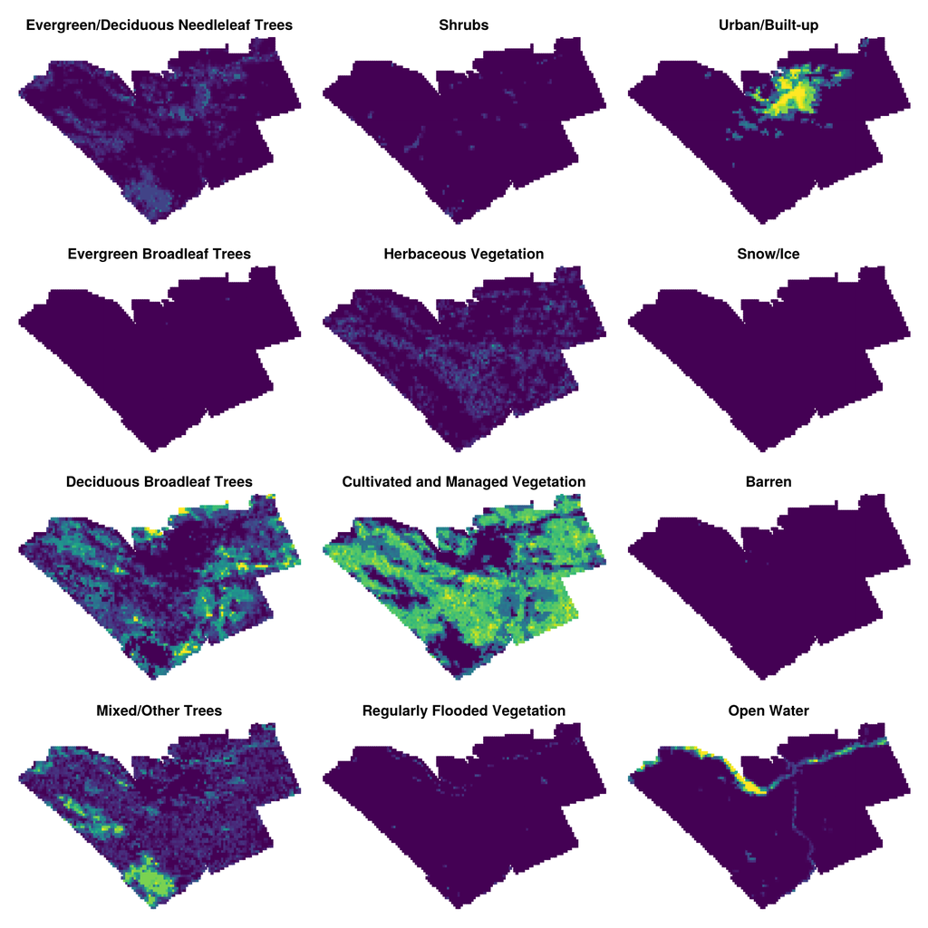

```julia
fig = Figure(size = (900, 900))
grid = GridLayout(fig[1,1])
grid_locations = CartesianIndices((1:4, 1:3))
for (i, cart_idx) in enumerate(grid_locations)
    ax = Axis(grid[cart_idx[1], cart_idx[2]], title = landcover_types[i])
    hidedecorations!(ax)
    hidespines!(ax)
    heatmap!(ax, stack[i], colorrange=(0,100))
end
fig
```

Now we’ll build a single consensus map by assigning each pixel the land cover type with the highest coverage. We use `mosaic`, which takes a function and a vector of raster layers and returns a layer formed by applying that function across layers at each cell. Here we use `argmax`, which returns the index of the layer with the highest value — i.e., the most prominent land cover type.

```julia
consensus = mosaic(argmax, stack);
```

First we define colors that clearly correspond to the land cover classes.

```julia
landcover_colors = [
    colorant"#117733",   # Needleleaf / Evergreen forest
    colorant"#668822",   # Broadleaf deciduous
    colorant"#99BB55",   # Mixed forest
    colorant"#55aa22",   # Shrubland
    colorant"#ddcc66",   # Grassland
    colorant"#aaddcc",   # Wetland
    colorant"#44aa88",   # Cropland
    colorant"#88bbaa",   # Barren / Sparse vegetation
    colorant"#bb0011",   # Urban
    :aqua,               # Water
    colorant"#FFEE88",   # Snow/Ice
    colorant"#5566AA",   # Other
]
```

```
12-element Vector{Any}:
 RGB{N0f8}(0.067, 0.467, 0.2)
 RGB{N0f8}(0.4, 0.533, 0.133)
 RGB{N0f8}(0.6, 0.733, 0.333)
 RGB{N0f8}(0.333, 0.667, 0.133)
 RGB{N0f8}(0.867, 0.8, 0.4)
 RGB{N0f8}(0.667, 0.867, 0.8)
 RGB{N0f8}(0.267, 0.667, 0.533)
 RGB{N0f8}(0.533, 0.733, 0.667)
 RGB{N0f8}(0.733, 0.0, 0.067)
 :aqua
 RGB{N0f8}(1.0, 0.933, 0.533)
 RGB{N0f8}(0.333, 0.4, 0.667)
```

And now we plot with a legend.

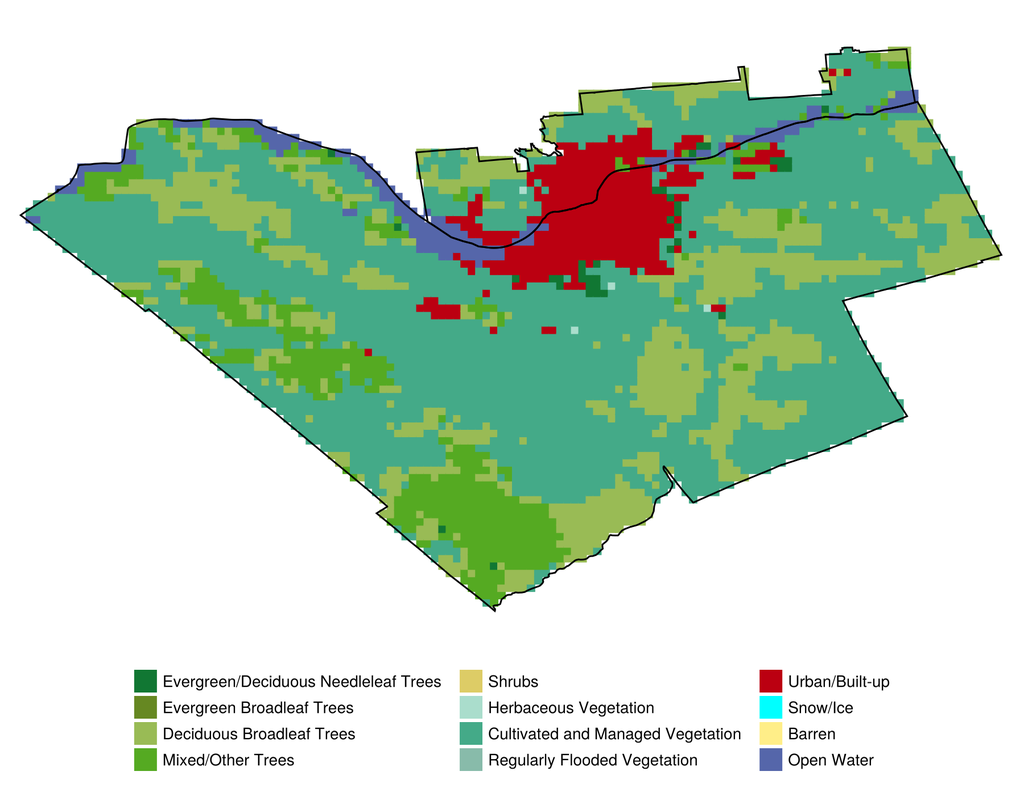

```julia
fig = Figure(; size = (900, 700))
panel = Axis(fig[1, 1]; xlabel = "Easting", ylabel = "Northing", aspect = DataAspect())
hidedecorations!(panel)
hidespines!(panel)
heatmap!(panel, consensus; colormap = landcover_colors)
lines!(panel, metro_region; color = :black, linewidth = 1.5)
Legend(
    fig[2, 1],
    [PolyElement(; color = landcover_colors[i]) for i in eachindex(landcover_colors)],
    landcover_types;
    orientation = :horizontal, nbanks = 4, framevisible = false
)
fig
```

Before running connectivity analysis, let’s demonstrate how we can use polygons to compute land cover statistics for each city. There is a fair amount going on here — the point is just to show how complex operations can be expressed concisely.

```julia
function count_area(x)
    lc_types = sort(unique(x))
    cell_counts = map(lc->count(isequal(lc), x), lc_types)
    return [landcover_types[lc] for lc in lc_types], [cell_counts[i] / sum(cell_counts) for i in eachindex(lc_types)]
end

cities = [x.properties[:name] for x in metro_region]
cover_by_city = Dict([metro_region[i].properties[:name] => x for (i,x) in byzone(count_area, consensus, [metro_region...])])
```

```
Dict{String, Tuple{Vector{String}, Vector{Float64}}} with 2 entries:
  "Ottawa"   => (["Evergreen/Deciduous Needleleaf Trees", "Deciduous Broadleaf …
  "Gatineau" => (["Evergreen/Deciduous Needleleaf Trees", "Deciduous Broadleaf …
```

Now we can plot as a side-by-side bar chart by putting this data in a table that works well with Makie’s bar plots.

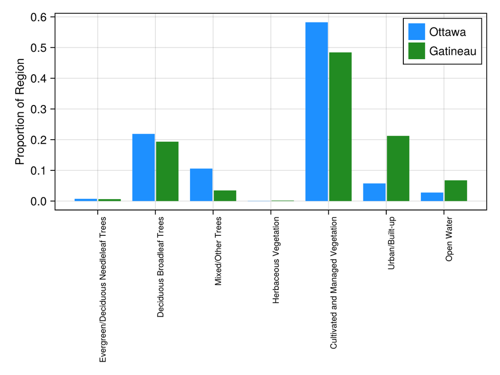

```julia
tbl = (
    cat = vcat([[i for i in eachindex(cover_by_city[k][1])] for k in cities]...),
    height = vcat([cover_by_city[c][2] for c in cities]...),
    grp = vcat([[i for j in eachindex(cover_by_city[c][1])] for (i,c) in enumerate(cities)]...)
)

fig = Figure()
ax = Axis(fig[1,1], xticks = (1:length(cover_by_city[cities[begin]][1]), cover_by_city[cities[begin]][1]), xticklabelsize = 10, xticklabelrotation=2.5π, ylabel = "Proportion of Region")
barplot!(ax,
    tbl.cat,
    tbl.height,
    dodge = tbl.grp,
    color = tbl.grp,
    colormap = [:dodgerblue, :forestgreen]
)
axislegend(ax, [PolyElement(color=:dodgerblue), PolyElement(color=:forestgreen)], cities)
fig
```

## Circuitscape

For our first connectivity analysis, we’ll use Circuitscape to do a pairwise analysis of connectivity between patches of forest habitat.

Let’s load the package.

```julia
using Circuitscape
```

We’ll use deciduous trees as the focal land cover of interest.

```julia
target_type = "Deciduous Broadleaf Trees"
target_label = findfirst(isequal(target_type), landcover_types)
```

```
3
```

The function below labels individual, contiguous patches of forest habitat. We’ll use these patch IDs as focal nodes for Circuitscape’s pairwise mode.

```julia
function find_patches(landcover, target::Integer)
    neighbors = ((-1, -1), (-1, 0), (-1, 1), (0, -1), (0, 1), (1, -1), (1, 0), (1, 1))

    nrows, ncols = size(landcover)
    matrix = landcover.grid
    result = fill(-1, nrows, ncols)
    visited = falses(nrows, ncols)
    patch_id = 1

    for i in 1:nrows, j in 1:ncols
        matrix[i, j] == target && !visited[i, j] || continue

        patch_id += 1
        queue = [(i, j)]
        visited[i, j] = true

        while !isempty(queue)
            r, c = popfirst!(queue)
            result[r, c] = patch_id
            for (dr, dc) in neighbors
                nr, nc = r + dr, c + dc
                if checkbounds(Bool, matrix, nr, nc) && matrix[nr, nc] == target && !visited[nr, nc]
                    visited[nr, nc] = true
                    push!(queue, (nr, nc))
                end
            end
        end
    end
    patches = copy(landcover)
    patches.grid .= result
    patches.indices[findall(isequal(-1), result)] .= 0
    return patches
end
```

```
find_patches (generic function with 1 method)
```

Now we’ll use this function to label all the patches of deciduous forest.

```julia
patches = find_patches(consensus, target_label);
```

Plot to verify.

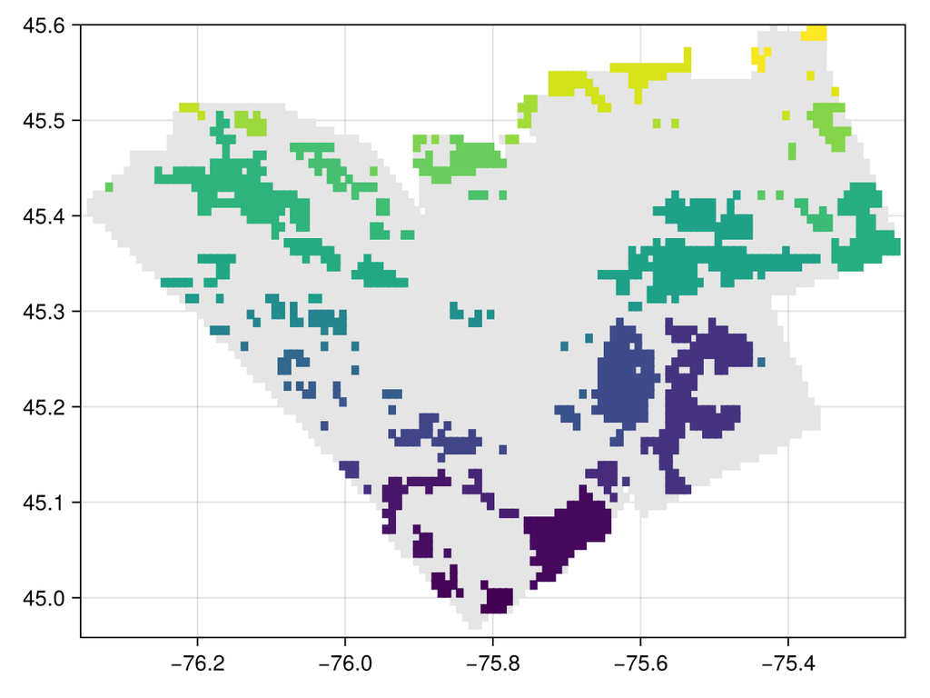

```julia
fig = Figure()
ax = Axis(fig[1,1])
heatmap!(ax, consensus, colormap=[:grey90])
heatmap!(ax, patches)
fig
```

Next we’ll create a resistance map by assigning each land cover class a resistance value.

```julia
resistance_values = Dict(
    "Evergreen/Deciduous Needleleaf Trees" => 1,
    "Evergreen Broadleaf Trees" => 1,
    "Deciduous Broadleaf Trees" => 1,
    "Mixed/Other Trees" => 1,
    "Shrubs" => 3,
    "Herbaceous Vegetation" => 3,
    "Cultivated and Managed Vegetation" => 10,
    "Regularly Flooded Vegetation" => 20,
    "Urban/Built-up" => 50,
    "Snow/Ice" => 50,
    "Barren" => 50,
    "Open Water" => 50
)
```

```
Dict{String, Int64} with 12 entries:
  "Evergreen/Deciduous Needleleaf Trees" => 1
  "Shrubs"                               => 3
  "Herbaceous Vegetation"                => 3
  "Deciduous Broadleaf Trees"            => 1
  "Open Water"                           => 50
  "Regularly Flooded Vegetation"         => 20
  "Cultivated and Managed Vegetation"    => 10
  "Evergreen Broadleaf Trees"            => 1
  "Mixed/Other Trees"                    => 1
  "Urban/Built-up"                       => 50
  "Snow/Ice"                             => 50
  "Barren"                               => 50
```

Create the resistance map by substituting each pixel’s land cover index with its corresponding resistance value.

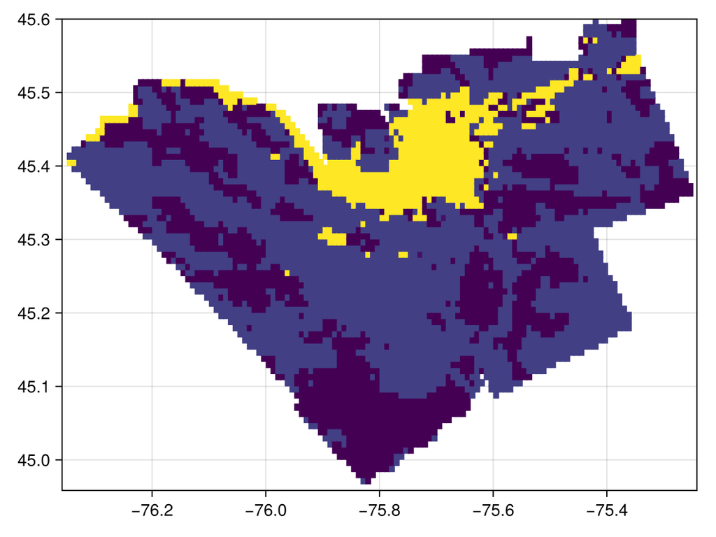

```julia
resistance = copy(consensus)
for i in eachindex(consensus)
    resistance[i] = resistance_values[landcover_types[consensus[i]]]
end

heatmap(resistance)
```

Circuitscape only runs using configurations defined in `.ini` files, so we need to write our input data in the expected ASCII raster format. The function below converts an `SDMLayer` to that format.

```julia
function write_raster(raster, output_path)
    open(output_path, "w") do io
        nrows, ncols = size(raster.grid)
        xll = raster.x[1]
        yll = raster.y[1]
        dx  = (raster.x[2] - raster.x[1]) / ncols

        println(io, "ncols         $ncols")
        println(io, "nrows         $nrows")
        println(io, "xllcorner     $xll")
        println(io, "yllcorner     $yll")
        println(io, "cellsize      $dx")
        println(io, "NODATA_value  -9999")

        raster.grid[findall(iszero, raster.indices)] .= -9999
        for row in eachrow(raster.grid)
            println(io, join(row, " "))
        end
    end
end
```

```
write_raster (generic function with 1 method)
```

Write the resistance map and the patch map to files.

```julia
write_raster(resistance, joinpath("circuitscape_inputs", "resistance.asc"))
write_raster(patches, joinpath("circuitscape_inputs", "patches.asc"))
```

Run Circuitscape.

```julia
Circuitscape.compute(joinpath("circuitscape_inputs", "config.ini"));
```

Circuitscape produces two outputs of note: a cumulative current map and a pairwise resistance matrix. The functions below load these back into Julia.

```julia
function load_cumulative_current(path, resistance)
    open(path) do f
        header = Dict()
        data_start = 0

        for (i, line) in enumerate(eachline(f))
            parts = split(strip(line))
            if length(parts) == 2
                header[lowercase(parts[1])] = parts[2]
            else
                data_start = i
                break
            end
        end
        nrows  = parse(Int,     header["nrows"])
        ncols  = parse(Int,     header["ncols"])
        nodata = parse(Float32, header["nodata_value"])

        seekstart(f)
        for _ in 1:data_start - 1
            readline(f)
        end

        grid = Matrix(undef, nrows, ncols)
        for i in 1:nrows
            vals = split(strip(readline(f)))
            for j in 1:ncols
                v = parse(Float32, vals[j])
                grid[i, j] = v == nodata ? nodata : v
            end
        end

        cumcurrent = copy(Float32.(resistance))
        cumcurrent.grid .= grid
        cumcurrent.indices[findall(isequal(nodata), cumcurrent.grid)] .= 0

        return cumcurrent
    end
end

using DelimitedFiles

function load_pairwise_resistance(path)
    mat = readdlm(path, ' ', Float64)
    mat[2:end, 2:end]
end
```

```
load_pairwise_resistance (generic function with 1 method)
```

Load the outputs.

```julia
cumulative_current  = load_cumulative_current(joinpath("circuitscape_inputs", "circuitscape_cum_curmap.asc"), resistance)
pairwise_resistances = load_pairwise_resistance(joinpath("circuitscape_inputs", "circuitscape_resistances_3columns.out"))
```

```
3159×2 Matrix{Float64}:
  5.0   0.919799
  6.0   1.34124
  7.0   1.20847
  8.0   1.31228
 10.0   1.15058
 12.0   1.09735
 14.0   3.80848
 15.0   8.08259
 16.0   6.01331
 17.0   8.00456
 18.0   7.55214
 21.0   1.71999
 22.0   5.68832
  ⋮
 90.0  23.1327
 91.0  25.5858
 87.0  23.5619
 88.0  22.033
 90.0  19.5797
 91.0  22.1006
 88.0  19.2216
 90.0  19.2702
 91.0  19.9909
 90.0  11.5102
 91.0   7.97573
 91.0   9.3113
```

Visualize the cumulative current map, with patches overlaid.

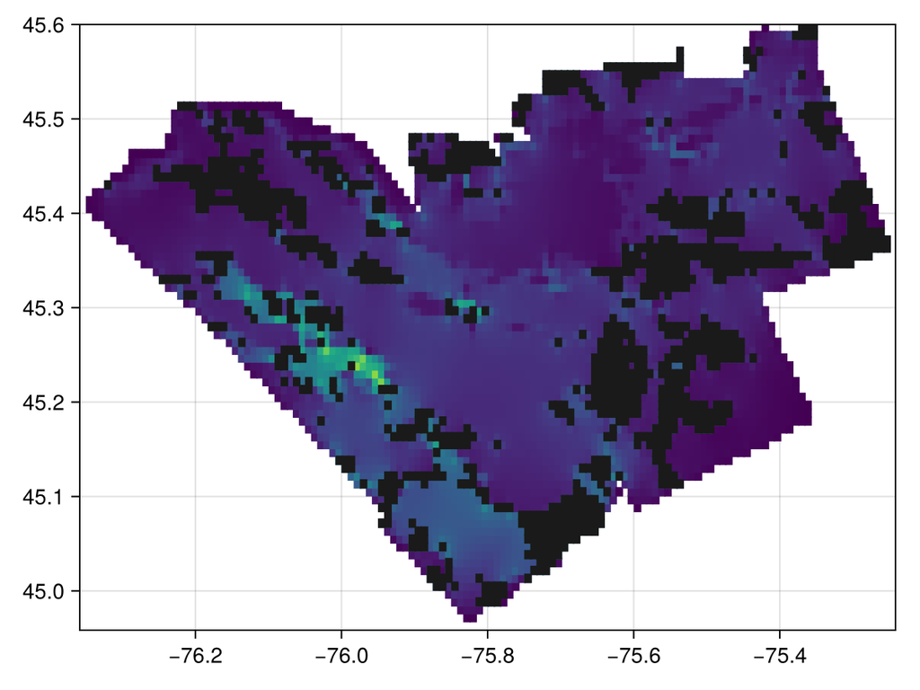

```julia
fig = Figure()
ax = Axis(fig[1,1])
heatmap!(ax, cumulative_current)
heatmap!(ax, patches, colormap=[:grey10])
fig
```

## Omniscape

Now we’ll use Omniscape to compute omnidirectional connectivity.

```julia
using Omniscape

function convert_resistance_to_omniscape(resistance)
    missing_idx = findall(.!resistance.indices)
    mat = Matrix{Union{Float64,Missing}}(resistance.grid)
    mat[missing_idx] .= missing
    return mat
end

omni_resist = convert_resistance_to_omniscape(resistance)

config = Dict{String, String}(
    "radius"                  => "50",
    "block_size"              => "1",
    "suppress_cs_messages"    => "true",
    "source_from_resistance"  => "true",
    "r_cutoff"                => "1",
    "reclassify_resistance"   => "false",
    "correct_artifacts"       => "false",
    "calc_normalized_current" => "true",
    "calc_flow_potential"     => "true",
    "project_name"            => "test",
    "write_outputs"           => "true",
    "parallelize"             => "false",
    "solver"                  => "cholmod",
)
```

```
Dict{String, String} with 13 entries:
  "correct_artifacts"       => "false"
  "calc_flow_potential"     => "true"
  "parallelize"             => "false"
  "block_size"              => "1"
  "reclassify_resistance"   => "false"
  "calc_normalized_current" => "true"
  "radius"                  => "50"
  "source_from_resistance"  => "true"
  "solver"                  => "cholmod"
  "r_cutoff"                => "1"
  "suppress_cs_messages"    => "true"
  "project_name"            => "test"
  "write_outputs"           => "true"
```

```julia
global_logger(ConsoleLogger(stderr, Logging.Warn))
currmap, flow_pot, norm_current = run_omniscape(config, omni_resist)
```

[output not shown]

[output not shown]

Convert the matrix outputs back to `SDMLayer`s for plotting.

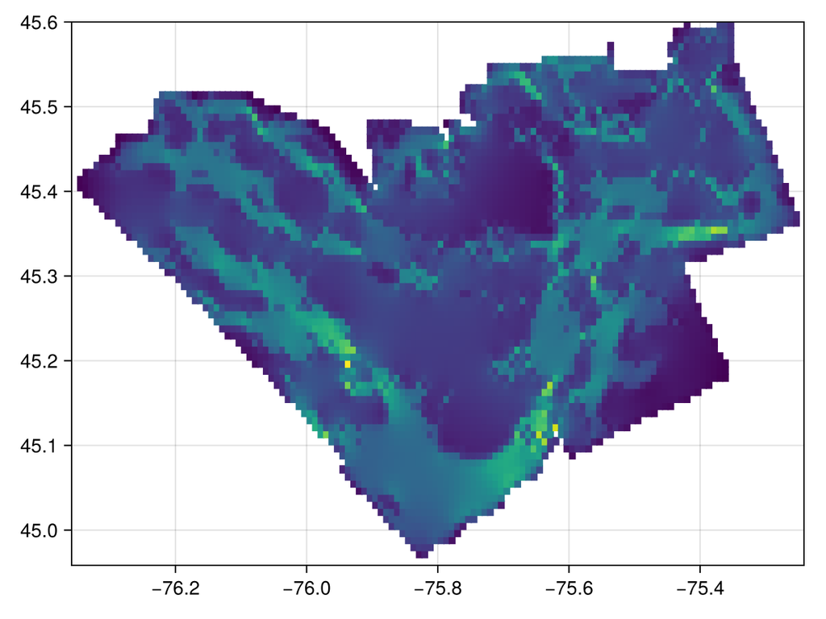

```julia
function convert_to_sdmlayer(matrix, resistance)
    valid_idx = findall(!ismissing, matrix)
    layer = copy(Float64.(resistance))
    layer.grid[valid_idx] .= matrix[valid_idx]
    return layer
end

current_map        = convert_to_sdmlayer(currmap, resistance)
flow_potential     = convert_to_sdmlayer(flow_pot, resistance)
normalized_current = convert_to_sdmlayer(norm_current, resistance)

heatmap(currmap)
heatmap(normalized_current)
```

## A Bigger Raster

Now we’re ready to run a larger connectivity analysis. We’ll use a pre-prepared land cover layer at a higher resolution (30 × 30 meter pixels) to avoid downloading 20 GB+ of data all at once.

```julia
landcover = SDMLayer(joinpath("data", "landcover.tif"));
```

This dataset uses a slightly different set of land cover classes.

```julia
landcover_types = [
    "Needleleaf forest",
    "Broadleaf deciduous forest",
    "Mixed Forest",
    "Shrubland",
    "Grassland",
    "Wetland",
    "Cropland",
    "Barren lands",
    "Urban",
    "Water",
]
```

```
10-element Vector{String}:
 "Needleleaf forest"
 "Broadleaf deciduous forest"
 "Mixed Forest"
 "Shrubland"
 "Grassland"
 "Wetland"
 "Cropland"
 "Barren lands"
 "Urban"
 "Water"
```

Define colors for each land cover type and plot.

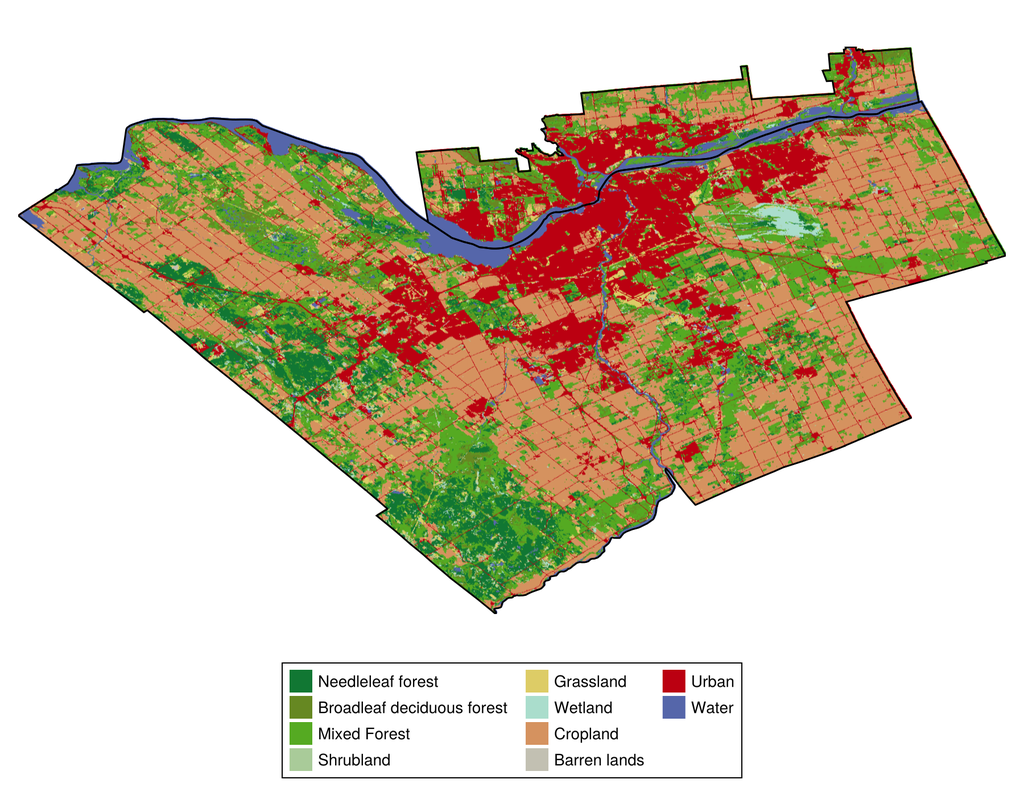

```julia
landcover_colors = [
    colorant"#117733",   # Needleleaf forest
    colorant"#668822",   # Broadleaf deciduous
    colorant"#55aa22",   # Mixed Forest
    colorant"#a9cb99",   # Shrubland
    colorant"#ddcc66",   # Grassland
    colorant"#aaddcc",   # Wetland
    colorant"#d5925f",   # Cropland
    colorant"#c2c0b2",   # Barren
    colorant"#bb0011",   # Urban
    colorant"#5566AA",   # Water
]

fig = Figure(; size = (900, 700))
panel = Axis(fig[1, 1]; aspect = DataAspect())
hidedecorations!(panel); hidespines!(panel)
heatmap!(panel, landcover; colormap = landcover_colors)
lines!(panel, metro_region; color = :black)
Legend(fig[2, 1],
    [PolyElement(; color = landcover_colors[i]) for i in eachindex(landcover_colors)],
    landcover_types; orientation = :horizontal, nbanks = 4)
fig
```

The higher resolution reveals considerably more spatial detail, which will be useful for connectivity analysis. Assign resistance values and build the resistance layer.

```julia
resistance_values = Dict(
    "Needleleaf forest"          => 1,
    "Broadleaf deciduous forest" => 1,
    "Mixed Forest"               => 1,
    "Shrubland"                  => 5,
    "Grassland"                  => 5,
    "Wetland"                    => 10,
    "Cropland"                   => 10,
    "Barren lands"               => 10,
    "Urban"                      => 50,
    "Water"                      => 50,
)

resistance = copy(Float32.(landcover))
for i in eachindex(landcover)
    resistance[i] = resistance_values[landcover_types[landcover[i]]]
end

omni_resist = convert_resistance_to_omniscape(resistance)

config = Dict{String, String}(
    "radius"                  => "30",
    "block_size"              => "3",
    "suppress_cs_messages"    => "true",
    "source_from_resistance"  => "true",
    "r_cutoff"                => "1",
    "reclassify_resistance"   => "false",
    "correct_artifacts"       => "false",
    "calc_normalized_current" => "true",
    "calc_flow_potential"     => "true",
    "project_name"            => "test",
    "write_outputs"           => "true",
    "parallelize"             => "false",
    "solver"                  => "cholmod",
)
```

```
Dict{String, String} with 13 entries:
  "correct_artifacts"       => "false"
  "calc_flow_potential"     => "true"
  "parallelize"             => "false"
  "block_size"              => "3"
  "reclassify_resistance"   => "false"
  "calc_normalized_current" => "true"
  "radius"                  => "30"
  "source_from_resistance"  => "true"
  "solver"                  => "cholmod"
  "r_cutoff"                => "1"
  "suppress_cs_messages"    => "true"
  "project_name"            => "test"
  "write_outputs"           => "true"
```

```julia
currmap, flow_pot, norm_current = run_omniscape(config, omni_resist)
heatmap(norm_current)
```

[output not shown]